# Project Business Statistics: E-news Express

## Univariate Analysis

- Categorical: group, landing page, converted, language preferred
- Numerical: time spent on the page

## Time spent on the page

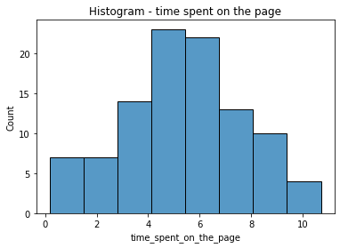

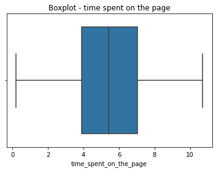

```python
sns.histplot(data=df, x='time_spent_on_the_page');
plt.title("Histogram - time spent on the page")
plt.show()
sns.boxplot(data=df, x='time_spent_on_the_page');
plt.title("Boxplot - time spent on the page")
plt.show()
```

- Time spent on the page follows a normal distribution
- While the time spent ranges from 0 ~ over 10 minutes, the median is approx 5.5 minutes
- 50% of the users spend time under 5.5 minutes

## Group

```python
df['group'].value_counts()
```

```
control      50
treatment    50
Name: group, dtype: int64
```

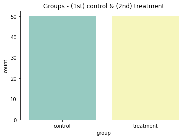

```python
sns.countplot(data=df, x='group', palette="Set3");
plt.title("Groups - (1st) control & (2nd) treatment");
```

- The countplot below shows that the group is divided into the first group (control) and second group (treatment)
- As stated in the objective, out of 100 random sampled users, they are equally divided into two groups

## Landing page

```python
df['landing_page'].value_counts()
```

```
old    50
new    50
Name: landing_page, dtype: int64
```

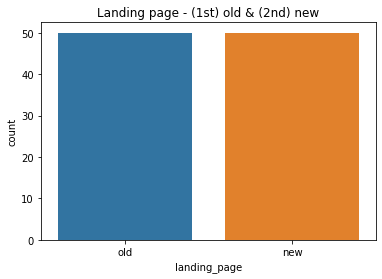

```python
sns.countplot(data=df, x='landing_page', palette="tab10");
plt.title("Landing page - (1st) old & (2nd) new");
```

- 100 random sampled users are equally divided into two groups
- As stated in the objective above, the existing "old" landing page is served to the first group (control)
- The "new" landing page is served to the second group (treatment)
- Therefore, 50 equally divided users served the old page, and other 50 users are served the new page

## Converted

```python
df['converted'].value_counts()
```

```
yes    54
no     46
Name: converted, dtype: int64
```

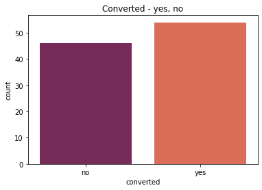

```python
sns.countplot(data=df, x='converted', palette='rocket');
plt.title("Converted - yes, no");
```

From the 100 randomly selected users, 54 users converted to a subscriber of the news portal, E-news Express and 46 users are not converted to a subscriber

- Since E-news Express's main goal to have new subscribers, it is essential to observe "yes" and "no" for the old & new landing page.

## Language preferred

```python
df['language_preferred'].value_counts()
```

```
Spanish    34
French     34
English    32
Name: language_preferred, dtype: int64
```

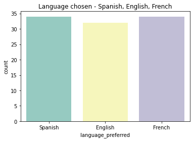

```python
sns.countplot(data=df, x='language_preferred', palette = "Set3");
plt.title("Language chosen - Spanish, English, French");
```

- Most users prefer Spanish, French, English approx equally for language chosen by the user to view the landing page
- This indicates that the mother language for 100 randomly chosen users are approximately 1/3 Spanish, English, and French
- Data itself won't be opinionated by the language chosen, but could show preferences

## Landing page (Group) vs time spent on the page

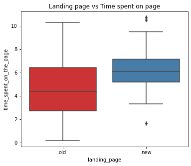

```python
plt.figure(figsize=(6,5))
sns.boxplot(data=df,x='landing_page',y='time_spent_on_the_page', palette='Set1')
plt.title("Landing page vs Time spent on page");
```

## Status - converted to subscriber vs time spent on the page

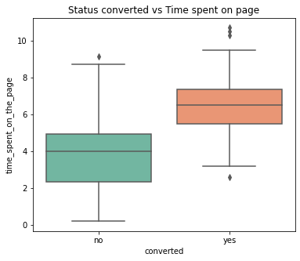

```python
plt.figure(figsize=(6,5))
sns.boxplot(data=df,x='converted',y='time_spent_on_the_page', palette='Set2')
plt.title("Status converted vs Time spent on page");
```

- 50% users who did not convert their subscriber status, ranges from approximately 02 ~ 05 minutes
- 50% users who did converted their subscriber status, ranges from 5 ~ 7 minutes
- Median is compared as (no) 4 minutes vs (yes) 6.5
- Users who changed their status of becoming a subscriber after the landing page, on average, spent more time on the page

## Language preferred vs time spent on the page¶

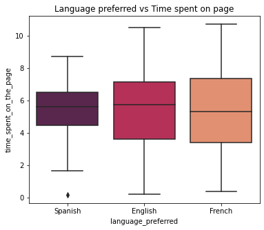

```python
plt.figure(figsize=(6,5))
sns.boxplot(data=df,x='language_preferred',y='time_spent_on_the_page', palette='rocket')
plt.title("Language preferred vs Time spent on page");
```

- Median for time on page, depending on language preferred is approximately the same
- Spanish speaking users' time spent on page is most concentrated of the median
- 50% French speaking users' time spent on page is the most dispersed from 03 to 07 minutes
- Therefore, the median time spent does not differ from language preferred

## 1. Do the users spend more time on the new landing page than the existing landing page?

## Perform Visual Analysis

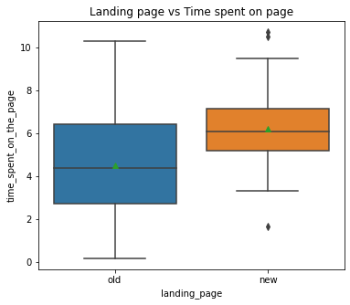

```python
plt.figure(figsize=(6,5))
sns.boxplot(data=df,x='landing_page',y='time_spent_on_the_page', palette='tab10', showmeans=True)
plt.title("Landing page vs Time spent on page");
```

## Step 1: Define the null and alternate hypotheses

$ \begin{array}{ll} H_0: & \mu1 = \mu2 \\ H_1: & \mu1 < \mu2 \end{array} $

## Step 2: Select Appropriate test

- The following test to be conducted is a One-tailed test concerning two population means from two independent populations
- The population standard deviations are unknown
- Continuous data: Time spent on the page is continuous data.
- Normally distributed populations
- Independent populations
- Random sampling from the population

From the relevant infomration above, sample means from 2 independent populations when standard deviation are unknown and therefore the 2-sample Independent. t-test should be used

## Step 3: Decide the significance level

With reference to the objective section, the significance level is 5%, α=0.05

## Step 4: Collect and prepare data

```python
new_page = df[df['landing_page']=='new']['time_spent_on_the_page']
old_page = df[df['landing_page']=='old']['time_spent_on_the_page']

print("new page sample std is", round(new_page.std(),2))
print("old page sample std is", round(old_page.std(),2))
```

```
new page sample std is 1.82
old page sample std is 2.58
```

- Unequal population standard deviations - As the sample standard deviations are different, the population standard deviations may be assumed to be different.
- Therefore: Two Independent Sample T-test for Equality of Means - Unequal Standard Deviation.

## Step 5: Calculate the p-value

```python
from scipy.stats import ttest_ind

test_stat, p_value = ttest_ind(old_page, new_page, equal_var = False, alternative = 'less')
print('The p-value is ', p_value)
```

```
The p-value is  0.0001392381225166549
```

## Step 6: Compare the p-value with α

```python
if p_value < 0.05:
    print('P-value {} is less than level of significance, therefore we reject the null hypothesis.'.format(p_value))
else:
    print('P-value {} is greater than the level of significance, we fail to reject the null hypothesis.'.format(p_value))
```

```
P-value 0.0001392381225166549 is less than level of significance, therefore we reject the null hypothesis.
```

## Step 7: Draw inference

- The p-value (0.00013923) is less than the level of significance, we can reject the null hypothesis.
- Therefore, we have enough evidence to support the claim that users spend more time on the new landing page than the existing landing page.

# 2. Is the conversion rate (the proportion of users who visit the landing page and get converted) for the new page greater than the conversion rate for the old page?

## Perform visual analysis

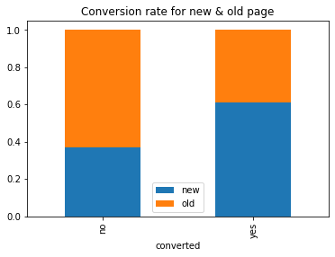

```python
table = pd.crosstab(df['converted'],df['landing_page'],normalize='index')
table.plot(kind='bar', stacked=True)
plt.title("Conversion rate for new & old page")
plt.legend()
plt.show()
```

## Step 1: Define the null and alternate hypotheses

$ \begin{array}{ll} H_0: & \mu1 = \mu2 \\ H_1: & \mu1 ≠ \mu2 \end{array} $

## Step 2: Select Appropriate test

#### np1 = 50 (21/50) = 21 >= 10 \ n(1-p1) = 50 (50-21/50) = 29 >= 10 \np2 = 50 (33/50) = 33 >= 10 \ n(1-p2) = 50 (50-33/50) = 17 >= 10

```python
pd.crosstab(df['converted'],df['landing_page'])
```

| landing_page converted | new | old |
| --- | --- | --- |
| no | 17 | 29 |
| yes | 33 | 21 |

## Step 3: Decide the significance level

With reference to the objective, the significance level is 5%, α=0.05

## Step 4: Collect and prepare data

```python
# convert_old: Converted status for first group (control group) - existing group
# convert_new: Converted status for second group (treatment group) - new landing group

old = df[df['group']=='control']['converted']
new = df[df['group']=='treatment']['converted']
# 'yes' from old first group (control group)
convert_old = old.value_counts()['yes']
# 'no' from new second group (treatment group)
convert_new = new.value_counts()['yes']
print('Number of users converted status for old group', convert_old)
print('Number of users converted status for new group', convert_new)
```

```
Number of users converted status for old group 21
Number of users converted status for new group 33
```

```python
# total numbers for control group and treatment group is 50 users each
total_control = df[df['group']=='control']['user_id'].count()
total_treatment = df[df['group']=='treatment']['user_id'].count()
print(total_control)
print(total_treatment)
```

```
50
50
```

## Step 5: Calculate the p-value

```python
from statsmodels.stats.proportion import proportions_ztest
test_stat, p_value = proportions_ztest([convert_old, convert_new],[total_control, total_treatment])
print('The p-value is ' + str(p_value))
```

```
The p-value is 0.016052616408112556
```

## Step 6: Compare the p-value with α

```python
if p_value < 0.05:
    print('P-value {} is less than level of significance, therefore we reject the null hypothesis.'.format(p_value))
else:
    print('P-value {} is greater than the level of significance, we fail to reject the null hypothesis.'.format(p_value))
```

```
P-value 0.016052616408112556 is less than level of significance, therefore we reject the null hypothesis.
```

## Step 7: Draw inference

- The p-value (0.01605261) is less than the level of significance, therefore, we can reject the null hypothesis.
- Evidence is enough to support the claim that the conversion rate for the new page is not equal to the conversion rate for the old page. Therefore, the new page could potentially be bigger than the conversion rate for the old page.

## 3. Is the conversion and preferred language are independent or related?

```python
df.head()
# Both categorical
# converted column (no, yes), preferred language (Spanish, English, French)
```

|  | user_id | group | landing_page | time_spent_on_the_page | converted | language_preferred |
| --- | --- | --- | --- | --- | --- | --- |
| 0 | 546592 | control | old | 3.48 | no | Spanish |
| 1 | 546468 | treatment | new | 7.13 | yes | English |
| 2 | 546462 | treatment | new | 4.40 | no | Spanish |
| 3 | 546567 | control | old | 3.02 | no | French |
| 4 | 546459 | treatment | new | 4.75 | yes | Spanish |

## Step 2: Select Appropriate test

- Categorical variables
- Expected value of the number of sample observations in each level of the variable is at least 5.
- Yes, the number of observations in each level is > 5.
- Random sampling from the population - With reference to the objective, we are informed that the collected sample is a simple random sample.
- Therefore, the chi-square test for independence should be used

## Step 3: Decide the significance level

With reference to the objective, the significance level is 5%, α=0.05

## Step 4: Collect and prepare data

```python
conversion_language = pd.crosstab(df['converted'], df['language_preferred'])
conversion_language
```

| language_preferred converted | English | French | Spanish |
| --- | --- | --- | --- |
| no | 11 | 19 | 16 |
| yes | 21 | 15 | 18 |

## Step 5: Calculate the p-value

```python
from scipy.stats import chi2_contingency

chi,p_value,dof,expected=chi2_contingency(conversion_language)
print('the p-value is', p_value)
```

```
the p-value is 0.21298887487543447
```

## Step 6: Compare the p-value with α

```python
if p_value < 0.05:
    print('P-value {} is less than level of significance, therefore we reject the null hypothesis.'.format(p_value))
else:
    print('P-value {} is greater than the level of significance, we fail to reject the null hypothesis.'.format(p_value))
```

```
P-value 0.21298887487543447 is greater than the level of significance, we fail to reject the null hypothesis.
```

## Step 7: Draw inference

As the p-value is much greater than the significance level, we cannot reject the null hypothesis. Hence, we do not have enough significance to conclude that conversion as a subscriber is dependent on preferred language at 0.05 significance level.

# 4. Is the time spent on the new page same for the different language users?

```python
df.head()
```

|  | user_id | group | landing_page | time_spent_on_the_page | converted | language_preferred |
| --- | --- | --- | --- | --- | --- | --- |
| 0 | 546592 | control | old | 3.48 | no | Spanish |
| 1 | 546468 | treatment | new | 7.13 | yes | English |
| 2 | 546462 | treatment | new | 4.40 | no | Spanish |
| 3 | 546567 | control | old | 3.02 | no | French |
| 4 | 546459 | treatment | new | 4.75 | yes | Spanish |

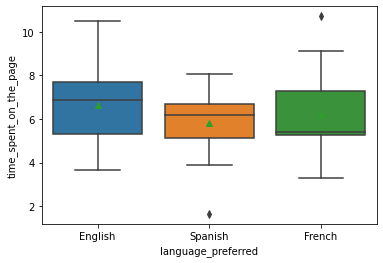

```python
# 'new' is users with the new landing page
new = df[df['landing_page']=='new']
# From 'new' users, let's see time spent for different language users
sns.boxplot(data=new, y='time_spent_on_the_page', x='language_preferred', showmeans=True, palette='tab10');
plt.show()
```

```python
new.groupby(['language_preferred'])['time_spent_on_the_page'].mean()
# Info below is the mean time spent on the new pages for each language users
```

```
language_preferred
English    6.663750
French     6.196471
Spanish    5.835294
Name: time_spent_on_the_page, dtype: float64
```

## Step 1: Define the null and alternate hypotheses

### $H_{0}$: The mean time spent on the new page for each language users are equal

### $H_{a}$: At least one of the mean time spent on the new page for language users is different

## Step 2: Select Appropriate test

- This problem deals with three population means, therefore, one-way ANOVA is an appropriate test if normality and equality of variance assumptions are verified.
- First, we use Shapiro-Wilk's test for normality and Leven test for equality of variance

## Shapiro-Wilk's Test

- null hypothesis- $H_{0}$: The time spent on the new page follows a normal distribution against the alternate hypothesis- $H_{a}$: The time spent on the new page do not follow a normal distribution

```python
import scipy.stats as stats
w, p_value = stats.shapiro(new['time_spent_on_the_page'])
print('The p-value is', p_value)
```

```
The p-value is 0.8040016293525696
```

Since p-value of the test is much larger than the 5% significance level, we fail to reject the null hypothesis, therefore, the time spent on the new page follows a normal distribution

## Levene's Test

- null hypothesis- $H_{0}$: All the population variances are equal against the alternative - $H_{a}$: At least one variance is different from the rest

```python
stat, p_value = stats.levene(new[new['language_preferred']=='English']['time_spent_on_the_page'],
                             new[new['language_preferred']=='Spanish']['time_spent_on_the_page'],
                             new[new['language_preferred']=='French']['time_spent_on_the_page'])
print('the p-value is', p_value)
```

```
the p-value is 0.46711357711340173
```

##### Since the p-value is larger than the 5% significance level, we fail to reject the null hypothesis that all population variances are equal

## Step 3: Decide the significance level

With reference to the above objective, the significance level is 5%, α=0.05

## Step 4: Collect and prepare data

```python
english = new[new['language_preferred']=='English']['time_spent_on_the_page']
spanish = new[new['language_preferred']=='Spanish']['time_spent_on_the_page']
french = new[new['language_preferred']=='French']['time_spent_on_the_page']
```

## Step 5: Calculate the p-value

```python
from scipy.stats import f_oneway

test_stat, p_value = f_oneway(english, spanish, french)
print('the p-value is', p_value)
```

```
the p-value is 0.43204138694325955
```

## Step 6: Compare the p-value with α

```python
if p_value < 0.05:
    print('P-value {} is less than level of significance, therefore we reject the null hypothesis.'.format(p_value))
else:
    print('P-value {} is greater than the level of significance, we fail to reject the null hypothesis.'.format(p_value))
```

```
P-value 0.43204138694325955 is greater than the level of significance, we fail to reject the null hypothesis.
```

## Step 7: Draw inference

- Since the p-value (0.43204138) is greater than the level of significance, we cannot reject the null hypothesis.
- Thus, we do not have enough statistical significance to claim that at least one of the mean time spent on the new page for language users is different. Therefore, support the claim that the mean time spent on the new page for each language users are equal.

# Conclusion and Business Recommendations

## Conclusion

- The primary goal for E-news Express,as an online news portal, is to attract more new monthly subscribers. From the executive's perspective, the reason for declining new subscribers is because the webpage is outdated and unattractive to customers.
- from 100 randomly sampled users, and dividing them equally into two groups: 50 users for the first old group (control group) and 50 users for the second new group (treatment group).
- After collecting data at a 5% significance level, the conclusion can be made as below for the following questions.
1. In terms of users spending time on the new landing vs existing landing
- From the 2-sample ind. t-test above, users on average do spend more time on the new landing page than on the existing page.
1. The conversion rate for new page vs conversion rate for old page
- In terms of conversion rate, proportion of users who visit the landing page and get converted to a subscriber, (the proportion of users who visit the landing page and get converted), according to the two-sample proportion z-test, the conversion rate for the new page is not equal to the conversion rate for the old page. Therefore, the possibility remains that the conversion rate for the new page is larger than the conversion rate for the old page.
1. Converted status dependency on preferred language
- Using chi-square test for independence, the converted status is independent from the preferred language
1. Time spent on the new page same for the different language users(English, Spanish, French)
- Using the one-way ANOVA, we cannot conclude that at least one language users' time spent on the new landing page is different from the rest.